# Exploring the BRFSS data

## Setup

### Load packages

```r
library(ggplot2)
library(dplyr)
library(pander)
library(tidyr)
library(knitr)
library(statsr)
```

### Load data

```r
load("~/Desktop/Intro_Prob_&_Data/Data Analysis Project/brfss2013.RData")
```

## Part 1: Data

BRFSS is an ongoing surveillance system designed to measure behavioural risk factors for the non-institutionalized adult population (18 years of age and older) The Behavioral Risk Factor Surveillance System (BRFSS) is a collaborative project between all of the states in the United States (US) and participating US territories and the Centers for Disease Control and Prevention (CDC). The BRFSS is administered and supported by CDC’s Population Health Surveillance Branch, under the Division of Population Health at the National Center for Chronic Disease Prevention and Health Promotion.

It’s objective is to collect uniform, state-specific data on preventive health practices and risk behaviours that are linked to chronic diseases, injuries, and preventable infectious diseases that affect the adult population.

The data refers to adult citizens (18 years age and older) that gives insights about aspects of their health and all the factors that may involve healthy -and unhealthy practices.

Data collection: the BRFSS is intented as an observational study with no form of interference, therefore all relationships between the different variables may indicate correlations.

The collected data for the survey stretches across all 50 states plus affiliated US territories including the District of Columbia, Guam, and the Commonwealth of Puerto Rico. The survey is generalizble to the US population as the observations and variables are distributed across the individuals background like, ethicity, educational background, income level etc.

In conducting the BRFSS landline telephone survey, interviewers collect data from a randomly selected adult in a household. In conducting the cellular telephone version of the BRFSS questionnaire, interviewers collect data from an adult who participates by using a cellular telephone and resides in private residence or college housing.

## Part 2: Research questions

the EDA project is largely aimed at general health and different variables that could might affect it.

**Research quesion 1:**

Are there differences between men and women suffering from depression, is there a possiblity that one is more prone in suffering from mental health issues?

variables that will be used are:

**sex** – : Respondents Sex (Male or Female) **menthlth** – : Number of Days Mental Health Not Good (1-30)

**Research quesion 2:**

**genhlth** – : General Health(Poor, Fair, Good, Very Good, Excellent) **sex** – : Respondents Sex (Male or Female) **income2** – : Income Level

**Research quesion 3:**

Is there a correlation between general health and education level?

**genhlth** – : General Health (Poor, Fair, Good, Very Good, Excellent) **sex** – : Respodents Sex (Male or Female) **educa** – : Educational level

## Part 3: Exploratory data analysis

**Research quesion 1: Are there differences between men and women suffering from depression, is there a possiblity that one is more prone in suffering from mental health issues ?**

The first research question is about the difference between the mental health between sex (male or female).

Filter out the NA’s in variables menthlth and sex and summarise.

```r
dataset <- brfss2013 %>%
  select(sex,income2, menthlth) %>% na.omit()
```

```r
dataset %>%
  group_by(sex) %>%
  summarise(mean=mean(menthlth), median=median(menthlth), sd=sd(menthlth))
```

```
## # A tibble: 2 x 4
##   sex     mean median    sd
##   <fct>  <dbl>  <dbl> <dbl>
## 1 Male    2.77      0  7.10
## 2 Female  3.89      0  8.10
```

One observation that we can make just purely out of the summarize function is, Females on average have more days mental health not good then Males.

Visualization

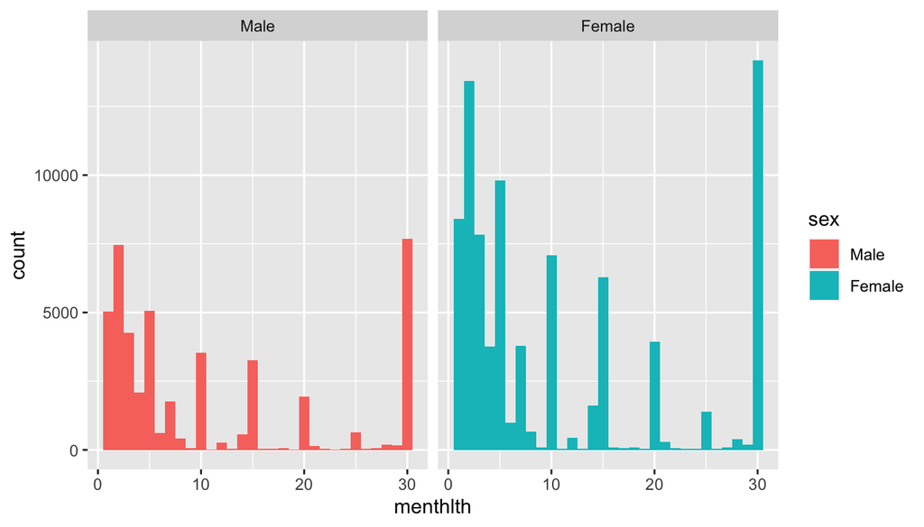

```r
dataset %>%
    filter(menthlth > 0) %>%
    group_by(sex) %>%
    ggplot(aes(x=menthlth, fill=sex)) +
    geom_histogram() +
    facet_wrap(~ sex, ncol=2)
```

Pre-processing data

```r
dataset2 <- brfss2013 %>%
  select(genhlth, income2, sex) %>% na.omit()
```

Short labels for readability.

```r
levels(dataset2$income2) <-c("-$10.000", "-$15.000", "-$20.000", "-$25.000", "-$35.000", "-$50.000", "-$75.000", "$75.000+")
```

Summary

```r
dataset2 %>%
  group_by(income2, sex) %>%
  summarize(Sum = n()) %>%
  spread(sex, Sum) %>%
  mutate(Sum = Male+Female, '% Male' = round(Male/Sum*100, digits = 1),  '% Female'= round(Female/Sum*100, digits =    1))
```

```
## # A tibble: 8 x 6
## # Groups:   income2 [8]
##   income2   Male Female    Sum `% Male` `% Female`
##   <fct>    <int>  <int>  <int>    <dbl>      <dbl>
## 1 -$10.000  8242  17010  25252     32.6       67.4
## 2 -$15.000  9145  17487  26632     34.3       65.7
## 3 -$20.000 12498  22207  34705     36         64
## 4 -$25.000 15645  25918  41563     37.6       62.4
## 5 -$35.000 19551  29136  48687     40.2       59.8
## 6 -$50.000 26723  34596  61319     43.6       56.4
## 7 -$75.000 29337  35765  65102     45.1       54.9
## 8 $75.000+ 56406  59253 115659     48.8       51.2
```

The table shows the percentage of Male and Females and their corresponding income levels. An observation can be made from the table is that as the income levels rises, the percentual distance between men and women decreases.

Visualization

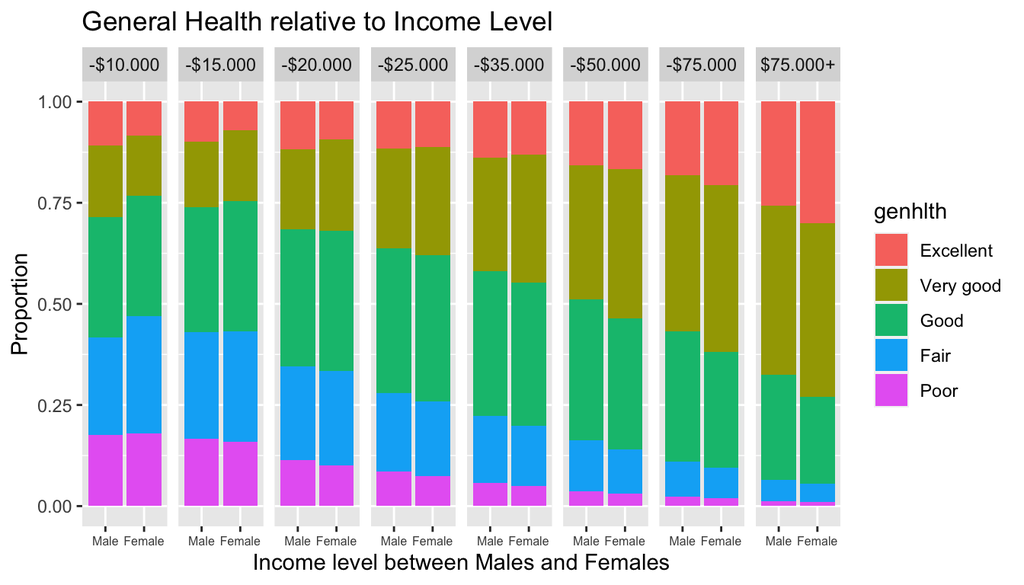

```r
ggplot(data = dataset2, aes(x=sex, fill=genhlth), labels) + geom_bar(position="fill") + facet_grid(.~income2) + theme(axis.text.x = element_text(size = 6)) + ggtitle("General Health relative to Income Level") + xlab("Income level between Males and Females") + ylab("Proportion")
```

The results plotted in the graph shows that General Health has some correlation with income level. “Poor” gradually declines, while “excellent” gradually increases as income level rises.

**Research quesion 3: Does educatinal level correlate with general health ?**

Pre-processing data

```r
dataset3 <- brfss2013 %>%
  select(genhlth, educa, sex) %>% na.omit()
```

Short labels for readability

```r
levels(dataset3$educa) <-c("Kindergarten", "Grade 1-8", "Grade 9-11", "Grade 12 or GED", "College 1-3", "College 4 +", " ", " ")
```

Summary

```r
dataset3 %>%
  group_by(educa, sex) %>%
  summarize(Sum = n()) %>%
  spread(sex, Sum) %>%
  mutate(Sum = Male+Female, '% Male' = round(Male/Sum*100, digits = 1),  '% Female'= round(Female/Sum*100, digits =   1))
```

```
## # A tibble: 6 x 6
## # Groups:   educa [7]
##   educa            Male Female    Sum `% Male` `% Female`
##   <fct>           <int>  <int>  <int>    <dbl>      <dbl>
## 1 Kindergarten      274    382    656     41.8       58.2
## 2 Grade 1-8        5672   7551  13223     42.9       57.1
## 3 Grade 9-11      11202  16703  27905     40.1       59.9
## 4 Grade 12 or GED 57706  84665 142371     40.5       59.5
## 5 College 1-3     51104  82635 133739     38.2       61.8
## 6 College 4 +     73555  96112 169667     43.4       56.6
```

visualization

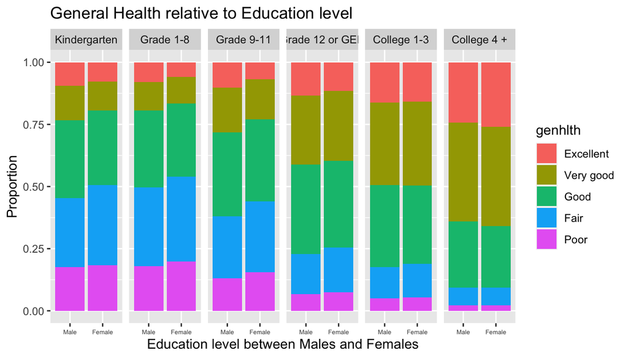

```r
ggplot(data = dataset3, aes(x=sex, fill=genhlth), labels) + geom_bar(position="fill") + facet_grid(.~educa) + theme(axis.text.x = element_text(size = 5)) + ggtitle("General Health relative to Education level") + xlab("Education level between Males and Females") + ylab("Proportion")
```

The results plotted in the graph shows that General Health has some correlation with education level. “Poor” gradually declines, while “excellent” gradually increases as Education level rises.